# Report: The impact of weather and bicycle traffic on bicycle theft in Berlin

## Introduction

### Motivation

Bicycle theft is a huge problem in Berlin, as it has one of [the highest rates of bike theft per inhabitant in Germany](https://www.wsm.eu/en/knowledge/bicycle-theft-in-germany/). This poses the question: How can one keep their bicycle safe in Berlin? Apart from a strong lock and a safe parking spot, there might be other influences on the probability of a bike being stolen, such as place or time of the day. A rather uncommon factor to think of is the weather, though it plays a huge part in mobility and transportation, especially for bicycles. Hypotheses that come to mind are:

- Less bikes are stolen on a rainy or snowy day.
- More bikes are stolen on sunny days as more people will ride their bike
- Thieves might be more reluctant to go out in the rain as well, and therefore, it might be safer for ones bicycle in the rain

To answer questions derived from these hypotheses, this project will combine three datasets from Berlin from 2022: one containing bicycle theft data, one containing different weather metrics and one containing bicycle traffic counts, look for anomalies and correlations in the data and try to draw conclusions from the results.

### Research questions

This report (mostly) follows the IMRAD structure, with subsections under Results and Discussion dedicated to answering the following research questions:

- RC1: Does more bicycle **traffic** lead to more bicycle **thefts**?
- RC2: Are there times where bikes, relative to traffic, are stolen more often?
- RC3: Do higher temperatures lead to more bicycle **traffic**?
- RC4: Do higher temperatures increase the risk of bicycle **theft**?
- RC5: Does more rain lead to less or more bicycle **traffic**?
- RC6: Does more rain increase the risk of bicycle **theft**?
- RC7: Are there significant differences in weather metrics at times when bikes were stolen?

### Prerequisites

To use this notebook, some packages are required.

```python
%pip install --quiet -r requirements.txt

import pandas as pd
import numpy as np
import sqlite3
import os
import matplotlib.pyplot as plt
import scipy
from datetime import datetime
import report_helpers
import importlib
importlib.reload(report_helpers)
```

```
<module 'report_helpers' from '/home/luca/Master/made-project/project/report_helpers.py'>
```

Before using this file further, please run the pipeline.py file **from the root folder** :

```
python3 project/pipeline.py
```

This will download the data and preprocess the data to create the SQLite database used for analysis. After this is done, you can run the following cells.

```python
# Read in the SQLite data
connection = sqlite3.connect("../data/bt_and_weather.sqlite")
dwd = pd.read_sql_query("SELECT * from dwd", connection)
bt = pd.read_sql_query("SELECT * from bicycle_theft", connection)
bcounts = pd.read_sql_query("SELECT * from count_bicycles", connection)
connection.close()

# Convert date columns to datetime
dwd  = report_helpers.convert_columns_to_datetime(dwd, ["date_hour"])
dwd.set_index("date_hour",inplace=True)

bt = report_helpers.convert_columns_to_datetime(bt, ["theft_begin_time","theft_end_time","created_time"])

bcounts = report_helpers.convert_columns_to_datetime(bcounts,["date_hour"])
bcounts.set_index("date_hour",inplace=True)
bcounts.drop(columns="index",inplace=True)

bt_2022 = report_helpers.filter_only_2022_data(bt, timecolumn="theft_begin_time")
dwd_2022 = report_helpers.filter_only_2022_data(dwd)
bcounts_2022 = report_helpers.filter_only_2022_data(bcounts)
```

## Methods

### The datasets

All data sets used are available under Open Data licenses that require attribution.

#### Weather data

**License: [Nutzungsbedingungen für Daten im CDC-OpenData Bereich](https://opendata.dwd.de/climate_environment/CDC/Nutzungsbedingungen_German.pdf)**

The weather data is from Deutscher Wetterdienst, a german goverment institution that is collecting and sharing weather data. They provide, amongst other data, hourly measurements of the temperature, humidity and precipitation, along with the type of precipitation (snow, rain) for different weather stations. The data for precipitation is provided in a seperate file from the air temperature data.  
As this analysis is focused on Berlin, the data used is from the station at Alexanderplatz in Berlin, as it is fairly central point in Berlin. Since the publication of bicycle theft data only started in the end of 2021, only weather data from the timespan January 1st 2022 to December 31 2022 considered in this analysis.

#### Bicycle theft data

**License: [CC BY 3.0 DE DEED](https://creativecommons.org/licenses/by/3.0/de/)**

The city of Berlin provides a large amount of Open Data, and one of the [most popular](https://daten.berlin.de/interaktion/artikel/daten-zu-fahrraddiebst%C3%A4hlen-vielseitig-genutzt) datasets is the bicycle theft dataset used in this project. To my knowledge, Berlin is also the only city in Germany that provides per-incident data on bicycle theft, most other cities only publish aggregated data which limits the space for analysis.  
The dataset is updated daily and provides extensive information about each datapoint, namely:

- the timeframe in which the theft occured (i.e. the time when the bike was last seen and when it was first discovered stolen), hourly
- the LOR code (a identifier) of the part of the city in which the theft occured
- the damage caused by the theft in euros
- the type of bike stolen
- if the theft was only an attempted theft
- the type of theft, f.e. if the theft involved breaking into private property

#### Bicycle count data

**License: [Datenlizenz Deutschland – Namensnennung – Version 2.0](https://www.govdata.de/dl-de/by-2-0)**

The city of Berlin also provides hourly data from bicycle counting stations across the city. Data from a station near Alexanderplatz (namely, Karl-Marx-Allee) is used to analyze the effects of the mobility on bicycle theft f.e. if the number of bicycle riders is correlated with the number of bikes stolen. This station is also one of the most popular station in terms of bicycles counted per day.  
As of January the 7th 2023, the dataset only contains bicycle counts up to the year 2022.

### Preprocessing

For this project, an automated data pipeline which is contained in the above mentioned `project/pipeline.py`. This pipeline will download the datasets (or use a already downloaded version if present), apply preprocessing steps and export the result to the respective table in the SQLite database contained in `data/bt_and_weather.sqlite`. The following paragraph describes the preprocessing steps for each of the datasets

#### Weather data

- Extract the required files from the downloaded ZIP archives
- Create the union of equal datasets to allow for possible extension to multiple weather stations etc.
- Join weather and temperature data
- Filter invalid measurements, namely those marked as invalid as well as temperature values below absolute zero or above 100 degrees Celcius.
- Drop unnecessary columns measuring formal quality and convert binary column to boolean
- For the type of precipitation: map the numbers to their meaning (taken from dataset specification), f.e. 7 == "solid" (meaning snow)
- Translate the remaining column names

#### Bicycle theft data

- Timestamps have seperate columns for date and hour -> join into a single column for timestamp
- Translate the values in the "VERSUCH" column to english
- Translate remaining column names to english
- Drop old unnecessary columns
- Check if the dataset is too new:
  - The dataset is updated daily by appending new data
  - At some point in the future, the maintainers could decide to archive old data seperately and the downloaded data could then be missing information from 2022
  - If this is the case, the user is propted to replace the link
- **Update January 7th: The relevant data was deleted and 2023 data cannot be used since the bicycle count dataset only goes up to 2022 (which will likely change very soon). Unfortunately, the maintainers do not provide download links to archived data, which is why the pipeline.py was modified to use a locally archived version contained in the repo. If they ever decide to upload the archived version, the link can be replaced.**

#### Bicycle count data

- Read the sheet "Jahresdatei 2022" from the XLSX file
- Read the values from the column for the counting station at Karl-Marx-Allee
- Fill missing values with 0

### Analysing the data

#### Assumptions

To simpify the analysis, a few assumptions have to be made.

First, it is assumed that the weather at Alexanderplatz is representative for Berlin as a whole. This is necessary as the other option would be using all the weather stations in Berlin, as well as using another dataset for translating the LOR location codes into coordinates. For the scope of this project, this seems excessive and would likely result in minimal differences.

Second, the same assumption is make about bicycle traffic, meaning that bicycle traffic at Karl-Marx-Allee is representative of Berlin as whole. When put in relation to the weather, this assumption should be fairly reliable as the station is quite close to the weather station used and is likely to serve as a good indicator for this relationship.

#### Challenges

The bicycle theft data contains time data in the the form of timeframes. For example, many thefts occur overnight, which means timeframe could be from the evening to the next morning. The weather data and the bicycle count data however is hourly, which means that it needs to be aggregated somehow for it to combined with the other data. As the length of the timeframes varies, the mean was chosen for aggregation (see results for RC7). In most of the analysis, the aggregation is done by grouping per calendar week an then aggregating this. For the bicycle theft data, the time at the start of the timeframe is used for grouping.

#### Analysis

For suitable relations, the correlation coefficent is calculated. Even though this deviates from the IMRAD structure, the descriptions of the individual analysis are provided along with the results for better readability.

[ If this is a problem, please imagine the paragraphs below every Results subtitle here ;) ]

## Results

### RC1: Does more bicycle **traffic** lead to more bicycle **thefts**?

The mean daily **bicycle theft and counts** are aggregated per calendar week and plotted. They are intentionally not aggregated per week directly as the first and last week of the year might be shorter than the other weeks. Additionaly, the correlation is calculated.

```
Correlation: 0.9064916000624873
```

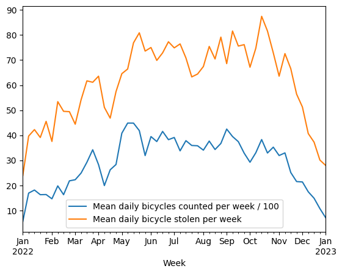

```python
# First, calculate the size/sum per day and then take the mean of that
# This way, the first and last week of the year (which could have less than 7 days) are represented correctly
thefts_per_week = bt_2022.set_index("theft_begin_time").resample("D").size().resample("W").mean()
bicycles_counted_per_week = bcounts_2022["bicycle_count"].resample("D").sum().resample("W").mean()
assert(thefts_per_week.size==bicycles_counted_per_week.size)
correlation_bc_bt = pd.DataFrame({
    "Mean daily bicycles counted per week / 100": bicycles_counted_per_week/100,
    "Mean daily bicycle stolen per week":thefts_per_week
}, index=thefts_per_week.index)
correlation_bc_bt.index.name = "Week"
print("Correlation: {}".format(thefts_per_week.corr(bicycles_counted_per_week)))
correlation_bc_bt.plot()
```

### RC2: Are there times where bikes, relative to traffic, are stolen more often?

From the **mean daily thefts per week** and **mean daily bicycle count per week**, a coefficent can be calculated which will be called the **Bicycle Danger Index** and expresses the number of thefts relative to the number of bike riders. This coeffient should express the relative risk of a bicycle being stolen and can be plotted to find seasonalities where bike theft is relatively speaking more likely. A Bike Danger Index higher than usual means that compared to the amount of bikes counted that week, more bikes than usual were stolen.

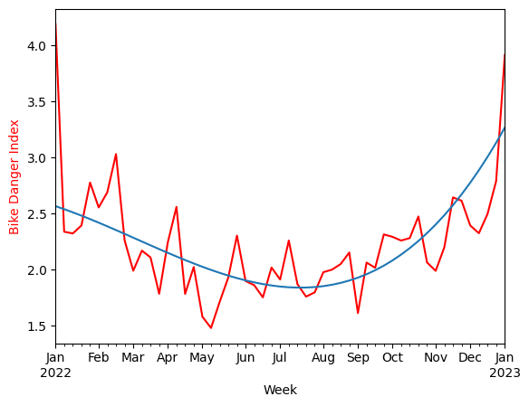

```python
bike_danger_index = thefts_per_week/(bicycles_counted_per_week/100.0)
bike_danger_index.plot.line(color="red")
plt.xlabel("Time")
plt.ylabel("Bike Danger Index", color="red")
report_helpers.plot_regression_line(bike_danger_index)
```

### RC3: Do higher temperatures lead to more bicycle **traffic**?

The **mean air temperature per week** is plotted against the **mean daily bicycle count per week** to analyse this relationship. Again, the correlation is calculated.

```
Correlation: 0.7615808870044775
```

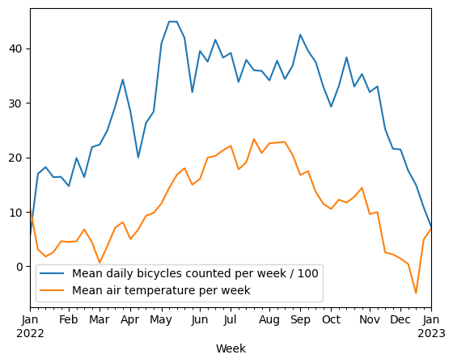

```python
mean_airtemp_per_week = dwd_2022["air_temperature"].resample("W").mean()
assert(mean_airtemp_per_week.size==bicycles_counted_per_week.size)
correlation_bc_at = pd.DataFrame({
    "Mean daily bicycles counted per week / 100": bicycles_counted_per_week/100,
    "Mean air temperature per week":mean_airtemp_per_week
}, index=mean_airtemp_per_week.index)
correlation_bc_at.index.name = "Week"

print("Correlation: {}".format(mean_airtemp_per_week.corr(bicycles_counted_per_week)))
correlation_bc_at.plot()
```

### RC4: Do higher temperatures increase the risk of bicycle **theft**?

The **mean air temperature per week** is plotted against the **Bike Danger Index** to analyse the influence of temperature on the risk of theft. Again, the correlation is calculated.

```
Correlation: -0.45017184666901366
```

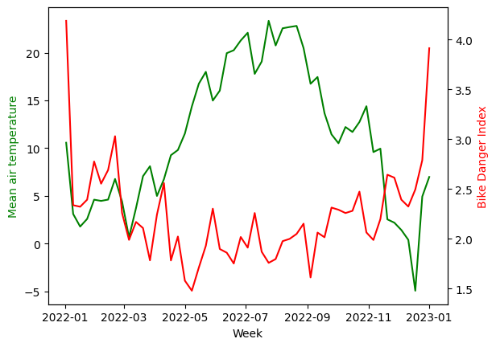

```python
avg_airtemps = dwd_2022["air_temperature"].resample("W").mean()
fig,ax = plt.subplots()
ax.plot(avg_airtemps, color="green")
ax.set_xlabel("Week")
ax.set_ylabel("Mean air temperature", color="green")
ax2 = ax.twinx()
ax2.plot(bike_danger_index, color="red")
ax2.set_ylabel("Bike Danger Index", color="red")
print("Correlation: {}".format(avg_airtemps.corr(bike_danger_index)))
plt.show()
```

### RC5: Does more rain lead to less or more bicycle **traffic**?

The **sum of the precipitation per week**, as well the number of **rainy hours in a week** are plotted against the **mean daily bicycle count per week** to analyse the influence of rain on bicycle traffic. As most of the year there is little rain in Germany, the weeks with a lot of rain (the peaks in the graph) are highlighted to see if they correlate with local minima in bicycle traffic.

```
Correlation: -0.006154462977104387
```

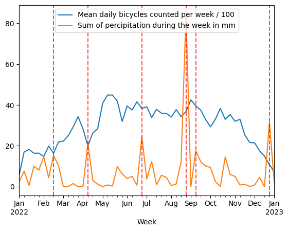

```python
precipitation_per_week = dwd_2022["precipitation"].resample("W").sum()
correlation_bc_pc = pd.DataFrame({
    "Mean daily bicycles counted per week / 100": bicycles_counted_per_week/100,
    "Sum of precipitation during the week in mm": precipitation_per_week
}, index=mean_airtemp_per_week.index)
correlation_bc_pc.index.name = "Week"

print("Correlation: {}".format(bicycles_counted_per_week.corr(precipitation_per_week)))
peaks = report_helpers.find_peaks(precipitation_per_week,min_value_for_peak=15)
correlation_bc_pc.plot()
report_helpers.show_plot_with_peaks(peaks)
```

```
Correlation: -0.006154462977104388
```

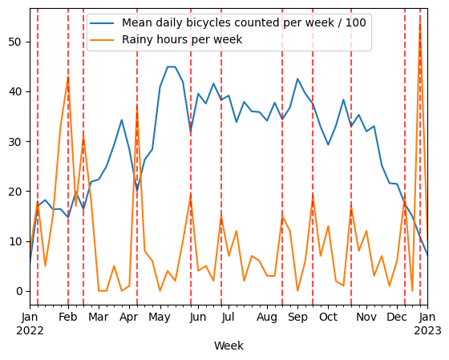

```python
rainy_hours_per_week = dwd_2022["precipitation"].resample("D").apply(lambda x:x.loc[x>0].size).resample("W").sum()
correlation_bc_rainyhours = pd.DataFrame({
    "Mean daily bicycles counted per week / 100": bicycles_counted_per_week/100,
    "Rainy hours per week": rainy_hours_per_week
}, index=mean_airtemp_per_week.index)
peaks = report_helpers.find_peaks(rainy_hours_per_week,min_value_for_peak=15)
correlation_bc_rainyhours.plot()
print("Correlation: {}".format(precipitation_per_week.corr(bicycles_counted_per_week)))
report_helpers.show_plot_with_peaks(peaks)
```

### RC6: Does more rain increase the risk of bicycle **theft**?

The number of **rainy hours in a week** is plotted against the **Bike Danger Index** to analyse the influence of rainy weeks on the risk of bicycle theft.

```
Correlation: 0.3914945074659926
```

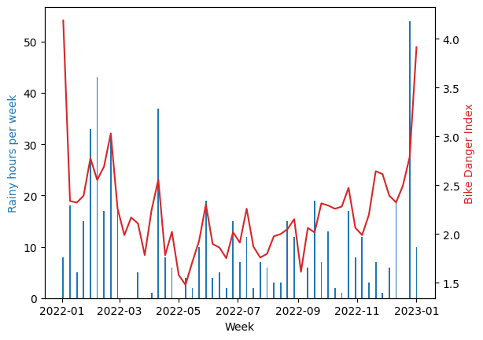

```python
fig,ax = plt.subplots()
ax.bar(x = rainy_hours_per_week.index,height=rainy_hours_per_week, width=1.5, color="tab:blue")
ax.set_xlabel("Week")
ax.set_ylabel("Rainy hours per week", color="tab:blue")
ax2 = ax.twinx()
ax2.plot(bike_danger_index, color="tab:red")
ax2.set_ylabel("Bike Danger Index", color="tab:red")
print("Correlation: {}".format(rainy_hours_per_week.corr(bike_danger_index)))
plt.show()
```

### RC7: Are there significant differences in weather metrics at times when bikes were stolen?

For **each bicycle theft**, the timeframe is obtained and joined with the corresponding hourly data from the **weather and bicycle count data**. Then, the **means** of most metrics are calculated, once for the entire year and secondly only for the timeframes from the bicycle theft and plotted. This way, a deviation in metrics during "bicycle theft hours" can be seen if there is one.

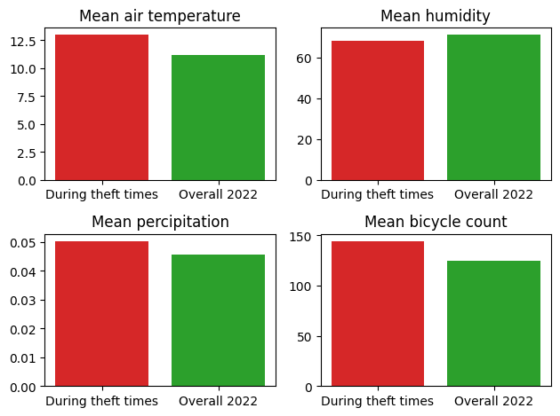

```python
weather_during_thefts = bt_2022.apply(lambda row: dwd_2022.loc[(dwd_2022.index>=row["theft_begin_time"])&(dwd_2022.index<=row["theft_end_time"])].mean(numeric_only=True), axis=1)
bicycles_counted_during_theft_times = bt_2022.apply(lambda row: bcounts_2022.loc[(bcounts_2022.index>=row["theft_begin_time"])&(bcounts_2022.index<=row["theft_end_time"])].mean(numeric_only=True), axis=1)

dwd_means= dwd_2022.mean(numeric_only=True)
during_thefts_means = weather_during_thefts.mean()
bc_mean_during_thefts= bicycles_counted_during_theft_times.mean()
bc_mean_overall = bcounts_2022.mean()


plot_names = ["Mean air temperature","Mean humidity","Mean precipitation", "Mean bicycle count"]
means_overall = [dwd_means["air_temperature"],dwd_means["humidity"],dwd_means["precipitation"],bc_mean_overall]
means_durings_theft = [during_thefts_means["air_temperature"],during_thefts_means["humidity"],during_thefts_means["precipitation"],bc_mean_during_thefts]
figure, axes = plt.subplots(2,2)
axes = axes.flatten()

for pltidx in range(len(plot_names)):
    ax = axes[pltidx]
    ax.bar("During theft times", means_durings_theft[pltidx], color="tab:red")
    ax.bar("Overall 2022", means_overall[pltidx],color="tab:green")
    ax.set_title(plot_names[pltidx])

plt.tight_layout()
plt.show()
```

## Discussion

### Limitations

- The data analysed is only for the year 2022, as this is currently the only full year for which all three datasets provide data. In the future, when more data is released, the analysis could be expanded to a new year to reduce the influence of events that could be specific to the year 2022. (f.e. in 2020, COVID lockdowns would have had a significant impact on mobility).
- The variation in bicycle theft and bicycle counts can obviously involve other factors, namely public holidays, school holidays, events affecting tourism and more.

## Conclusion

The results tend to show that it is safer for ones bicycle to be ridden during on warm days and days with little to no rain. In general, these correlations are closely related with the number of other people riding their bike on a given day, which means that being one of the fewer people cycling during bad weather should rather be avoided if one wants to reduce the chances of their bike being stolen (and getting wet). However, some of the correlations are not as strong, which could mean that other factors also play a large part. Further research should be done to identify those.

### Outlook

- The datasets could be expanded by using more weather and bicycle counting stations, along with mapping bicycle thefts to their nearest bicycle counting station. This would reduce the assumptions made in the Methods chapter and provide a more realistic view. For example, so some districts of Berlin will likely have higher bicycle theft rates, which is neglected in this analysis.
- Further research could try to use the data from 2022 to train a Machine Learning model and test it on data that it released in the future.
- The other parameters from the bicycle theft datasets could be analysed further, for example to see if there is a correlation of the value of stolen bicycles and other factors.
- The other parameters from weather data could be used as well when looking for correlations with other metrics, for example **differentiating between rain and snow**.
- Other datasets, for example for public holidays, could be taken into account.